# 1.0.0

## LOs:

1. Analyse the goals and purpose of artificial intelligence, and distinctions between approaches such as acting rationally and simulating human behaviour. (MLO 4)
2. Understand Lady Lovelace’s objection, The Turing Test and the Chinese Room of “whether machines can think?” (MLO 4)
3. Articulate the arguments for and against weak AI and strong AI. (MLO 4)
4. Identify some of the methods of current AI research and be able to give examples of their application in state-of-the-art AI systems. (MLO 4)
5. Identify and critically evaluate the potential threats to society posed from recent development in AI. (MLO 4).

# 1.0.1

## Activities:

1. Considering the meaning of artificial intelligence, with four proposed definitions of AI, and thinking about how each definition would affect the nature of research in the field;
2. Considering some of the philosophical debate around artificial intelligence;
3. Reading about state-of-the-art AI systems that are being researched or are under development, and writing a short review of some of the research identified;
4. Discussing the research mentioned above in small groups, and answering some questions about them as a group. You will need to consider the ethical and technical aspects of deploying an AI system in the real world.

# 1.0.3

## Reading:

### Lesson 1

- Russell S., Norvig P. (2016) Artificial Intelligence: A Modern Approach, Fourth Edition. Chapter 1, sections 1.1 to 1.2.

### Lesson 2

- Russell S., Norvig P. (2016) Artificial Intelligence: A Modern Approach, Fourth Edition. Chapter 28, sections 1&2.

### Lesson 3

- Baibach N. & Hogarth I. (2023) State of AI Report available online from https://www.stateof.ai/

### Lesson 4

- Russell S., Norvig P. (2016) Artificial Intelligence: A Modern Approach, Fourth Edition Edition. Appendix A, A1.
- Russell S., Norvig P. (2016) Artificial Intelligence: A Modern Approach, Fourth Edition. Chapter 28, section 3.

### Further reading:

- [Will self driving cars reduce energy use and make travel better for the environment?](https://theconversation.com/will-self-driving-cars-reduce-energy-use-and-make-travel-better-for-the-environment-55363)
- [The trolley dilemma - would you kill one person to save five?](https://theconversation.com/the-trolley-dilemma-would-you-kill-one-person-to-save-five-57111)
- [No need to panic artificial intelligence has yet to create a doomsday machine.](https://theconversation.com/no-need-to-panic-artificial-intelligence-has-yet-to-create-a-doomsday-machine-35148)
- [AI and the future of work - 5 experts on what chatgpt, dall e and other ai tools mean for artists and knowledge workers.](https://theconversation.com/ai-and-the-future-of-work-5-experts-on-what-chatgpt-dall-e-and-other-ai-tools-mean-for-artists-and-knowledge-workers-196783)
- [What if your colleague is a bot - harnessing the benefits of workplace automation without alienating staff.](https://theconversation.com/what-if-your-colleague-is-a-bot-harnessing-the-benefits-of-workplace-automation-without-alienating-staff-196203) .

# 1.5.0

## 1.5 What is AI?

Intelligence: the power of learning, understanding and reasoning; mental ability

Can break these down into functions:

- mental functions (the functions of the mind) are functions of:
  - inputs (sensory)
  - outputs (motor functions)
  - these enable us to:
    - learn
    - record (memory)
    - reason (think)
    - act (through motor functions)

### Common Features:

The human brain:

- multi sensory input
- recall / memory / experience
- reasoning / cognitive functions
- personality / communication / expression
- autonomic functions

A computer system:

- interface / multiple inputs
- memory / storage / code / data
- processing / algorithms
- interface / multiple outputs
- automation

### Key Differences

Humans are good at:

- recognising patterns in unstructured information
- solving problems without instructions
- making connections, between info across domains
- acting and functioning spontaneously or independently

Computers are good at:

- complex and repetitive calculations accurately
- gathering, collating, storing, manipulating, analysing and retrieving data
- searching through data
- carrying out sequences of instructions

### Programmed intelligence

- programming a computer to appear intelligent
- is just an exptrapolation of the intelligence of the designer
- can be thought of the lowest kind of weak AI

### AI

- thinking humanly
  - decision making
  - problem solving
  - learning
- thinking rationally
  - with enough data can a computer solve a problem without being programmed to do so
- acting humanly
  - creating machines that can perform tasks that humans are good at after training
  - communicating using natural language
  - showing creativity or spontaneity
- acting rationally
  - controlling vehicles
  - conducting searches
  - extracting data/information
  - logical reasons yielding logical results

The debate between rationalists and humanists results in:

- flexibility with how we define AI

### When is an AI solution of value?

- Even though it is often possible to develop algorithms to address problems, some problems do not lend themselves to being solved algorithmically (and in some cases may not be solved at all) or require inefficient, brute-force computation and in these cases AI solutions may be a more efficient or effective alternative.
- Equally, however, there are many problems that can be solved both efficiently and effectively without the need for AI and in those cases an AI solution may in fact be less desirable.

# 1.7.0

## 1.7 Is Artificial Intelligence Possible?

### Lady Lovelace’s Objection

- Translating to mean computers cannot really think because they can only do what they have been programmed to do

### Alan Turing's rebuttal of the Objection

- In practice, the results of programming often surprise us. (Lady Lovelace never got to run any of her programs!)
- The possibility that machines could be programmed to learn.

# 1.7.1

### The Turing Test

- The questioner interrogates the respondents within a specific subject area, using a specified format and context.
- After a preset length of time or number of questions, the questioner is then asked to decide which respondent was human and which was a computer.
- The test is repeated many times. [[1]](https://www.techtarget.com/searchenterpriseai/definition/Turing-test).

### Strong and Weak AI

- Weak: A machine that acts as if it thinks like a human.
- Strong: A machine that thinks like a human.

# 1.7.2

### John Searle’s Chinese Room

In 1980 John Searle published “The Chinese Room Argument” in journal to demonstrate the difference between weak AI and strong AI:

Minor variation:

- English-speaking person locked in a room
- has no knowledge of Chinese or Russian.
- given texts written in Chinese.
- Also in the room is a set of rules, written in English, for manipulating the symbols of Chinese text and producing Russian translations.
- By carefully and methodically following these rules, the person produces accurate Russian translations of the Chinese text.
- Searle argues that the room-plus-person system behaves as if it understands Chinese, while it is obvious that no understanding is involved.
- Hence behaviour does not imply the existence of a mind that understands. Or to put it another way, weak AI does not imply strong AI.
- Thus, the Turing test is not a valid criterion/method for assessing whether a machine can think.

# 1.7.3

### Isaac Luis Wain

- The test relies on the interrogator to be a good adjudicator. Would a machine pass the Turing test if it can convince a young child? At what point is the interrogator considered competent enough to make a good judgement?
- The test assesses the machine's ability to imitate a human's responses, but does not assess the machine's ability to think or reason
- It is of limited use in a modern context where LLMs can successfully imitate human speech patterns in many cases but lack the ability to create truly original ideas

### Shayan Khan

- The test only provides surface-level interaction; it evaluates the machine's ability to mimic human behavior but ignores factors such as reasoning and understanding
- It is easy for a machine to pass the test by employing deceptive tactics by mimicking human responses without actually understanding the supplied content.
- There us subjectivity involved; different judges hold different criteria for passing the test with "human-like" behavior
- The test only evaluates linguistics and not factors such as emotional and visual understanding .

# 1.9.0

## Evaluating AI Solutions

### Non-computable problems

when a problem cannot be solved satisfactorily in a finite amount of time

- e.g. fully calculating $\pi$ (Pi)

### Termination criteria

accepting an incomplete result because it does well enough for our requirements e.g.

- stop after $n$ iterations
- stop at a specific number of decimal places
- stop when the result is in a specific range

### Brute Force vs AI

apply AI to the solution instead of brute force when:

- an AI solution is faster
- a problem doesn't lend itself to a mathematical solution
- a problem doesn't lend itself to a logical solution

### Evaluating Effectiveness

Use an AI solution over a current one when the AI solution is:

- at least as effective and more efficient
- more effective and at least as efficient
- more effective and more efficient
- evaluate this with:
  - accuracy
  - noise
  - loss
  - overfitting/underfitting
  - generalisability
  - efficiency: how long it take

#### Simple Problem Efficiency

- Solutions scale linearly with problem size.
- Example: Time t for one item, t*n for n items.

#### Complex Problem Efficiency

- Solutions do not scale linearly; involve polynomial time.
- Consider non-deterministic polynomial time for predictions.

#### Finite Time Considerations

- Solutions should achieve satisfactory results within measurable time.
- Early termination can still yield verifiable outcomes.

#### NP-Complete Problems

- Solvable by brute force; solutions quickly verifiable.
- Heuristic AI approaches can efficiently return results.

#### Polynomial Time

- Time taken by general-purpose computers for complex problem solutions.
- Relevant for evaluating AI solution feasibility.

#### Heuristic Approaches in AI

- Provide quick results for NP-complete problems.
- Enhance AI effectiveness in complex scenarios.

#### Scalability of Solutions

- Important for both simple and complex problem-solving.
- Ensures solutions remain effective as problem size increases.

#### Reliability of AI Solutions

- AI can reliably solve non-computable problems satisfactorily.
- Enhances overall problem-solving capabilities beyond traditional methods.

#### Iterative Refinement

- Solutions may improve through multiple iterations.
- Important for achieving satisfactory outcomes in finite time.

#### Verification of Solutions

- Ensures results are accurate and meet criteria.
- Critical for validating AI and computational methods.

#### Resource Allocation

- Efficient use of computational resources is essential.
- Balances speed and accuracy in solution development.

#### AI vs Traditional Methods

- AI offers intuitive approaches that can be faster and more efficient.
- Traditional methods may require extensive computational steps.

#### Solution Metrics

- Use specific metrics to evaluate effectiveness and efficiency.
- Important for training and validating AI models.

## ETHICS

#### Moral Responsibility:

- Positive applications include medical advancements, disaster recovery, environmental protection, crime prevention, and more.
- AI can democratise technology access but may also centralise power.

#### Positive Impacts:

- AI enhances healthcare, business productivity, and environmental sustainability.
- It improves safety (e.g., driver assistance, disaster prediction) and supports marginalised groups, such as people with disabilities.

#### Negative Aspects:

- AI may widen income inequality by concentrating wealth.
- Automation might disrupt developing countries' growth models.
- Ethical challenges mirror those of past technologies like nuclear power and fossil fuels.

### AI Principles

- Ensure safety
- Fairness
- Respect privacy
- Promote collaboration
- Be transparent
- Limit harmful uses
- Accountability
- Uphold human rights/values
- Be diverse and inclusive
- Avoid concentration of power
- Acknowledge legal and policy implications
- Lethal Autonomous Weapons

#### Definition and Use:

- These weapons autonomously select and engage targets without human input.
- They represent a "third revolution in warfare" after gunpowder and nuclear weapons.
- Currently, only a few systems possess full autonomy (e.g., Israel’s Harop missile).

#### Legal and Ethical Concerns:

- Legal questions focus on discrimination, necessity, and proportionality in warfare.
- Ethically, delegating life-or-death decisions to machines is controversial.
- Many nations and NGOs support banning such weapons, citing moral objections.

#### Reliability Issues:

- Autonomous systems are unreliable in complex combat scenarios, as demonstrated by historical incidents like the 1983 Soviet missile false alarm.
- The potential for cyberattacks and malfunctions raises serious concerns.

#### Scalability and Mass Destruction:

- Autonomous weapons can be mass-produced and deployed with minimal human oversight.
- They pose new threats, especially to non-state actors, and increase global instability.

### Surveillance, Security, and Privacy

#### Surveillance:

- AI-powered mass surveillance, such as voice and facial recognition, is widespread, with over 350 million cameras in China.
- Exporting surveillance tech raises ethical concerns, especially in countries with poor human rights records. Engineers must consider human rights compatibility.

#### Cybersecurity:

- AI is a double-edged sword in cybersecurity. It helps detect cyberattacks (like phishing and ransomware) but is also used to perpetrate them.
- Machine learning plays a crucial role in defending against these threats.

#### Privacy and Data Use:

- Growing online presence leads to increased data collection by governments and companies, raising privacy concerns.
- Laws like GDPR and HIPAA enforce data protection standards. Techniques such as de-identification, k-anonymity, and differential privacy help protect individual data, but challenges like re-identification persist.

#### Federated Learning:

- Keeps user data private while improving machine learning models by aggregating parameters rather than raw data. Secure aggregation ensures privacy during this process.

### Fairness and Bias

#### Bias in AI:

- AI systems can perpetuate societal biases, particularly in critical areas like criminal justice, lending, and hiring.
- Engineers have a moral and legal responsibility to ensure fairness.

#### Fairness Criteria:

- individual fairness - individuals from all classes treated same
- group fairness - different classes treated similarly
- fairness through unawareness - potential to remove identifying attributes to encourage fairness (although ML can still predict with other variables)
- equal outcome - same outcomes regardless of class (demographic parity)
- equal opportunity - equal chance of being correctly classified regardless of identifying variables (this can produce unequal outcomes but has no bias)
- equal impact - expecting the same utility of someone regardless of their class
- Achieving balance between these is complex and often impossible.

#### Addressing Bias:

- debiasing data
- Oversampling from minority groups
- Hierarchical modelling
- Train a second system to de-bias first system recommendations
- bias awareness training
- creating more representative training sets
- using new machine learning models
- enhancing algorithm transparency with annotations
- diversity in engineering teams
- system tests to reflect minority experiences
- collaboration between software engineers, social scientists, and domain experts
- incorporate feedback loop for bias issues

### Trust and Transparency

#### Trust Concerns:

Trust is crucial for AI adoption. A 2017 PwC survey showed that 76% of businesses delayed AI adoption due to trust issues.

#### Verification and Validation (V&V):

- For AI systems, V&V ensures the system meets specifications (verification) and fulfils user needs (validation).
- AI's V&V process needs improvements, especially in ensuring accuracy, fairness, and resistance to adversarial attacks.

#### Certification:

- Certification (e.g., UL certification for appliances) could increase AI trust.
- Frameworks like IEEE P7001 are being developed, but industry-wide standards are still in progress.

#### Transparency and Explainability:

- Transparency is key; consumers should know how AI systems work.
- Explainable AI (XAI) provides understandable, specific explanations for decisions, but explanations are not foolproof and can be misleading if not properly audited.

### Robot Rights

#### Robot Consciousness and Rights:

- The question of robot consciousness affects whether robots deserve rights.
- If robots can feel pain or fear death, they may be entitled to rights similar to historically oppressed groups.

#### Ethical Implications:

- Granting robots rights raises complex issues, such as the ethics of reprogramming and voting rights for autonomous entities.

#### Human–Robot Hybrids:

- As humans increasingly integrate technology, the boundary between human and machine blurs, complicating ethical considerations.

### AI Safety

#### Safety Engineering in AI:

- Traditional safety engineering practices, like Failure Modes and Effects Analysis (FMEA) and Fault Tree Analysis (FTA), are applied to AI to mitigate risks.
- These processes help anticipate failure points and ensure systems degrade gracefully under failure conditions.

#### Challenges in Utility Maximisation:

- AI agents optimising for utility functions can produce unintended harmful effects, such as damaging environments to achieve goals.
- Concepts like low impact designs reduce the chance of unintended harm, requiring agents to prefer minimal disruption.

#### Specification Failures:

- AI agents may exploit bugs or system limitations to achieve their objectives in ways that are unintended, showcasing the importance of robust specification and design.

#### Value Alignment Problem:

- Ensuring that AI systems' goals align with human values is critical, often referred to as the "King Midas problem."
- It highlights the difficulty of defining utility functions that account for societal norms and human preferences.

#### Imitation Learning & Apprenticeship:

- AI systems can learn human behaviour through observation, but can also replicate human errors.
- Techniques like inverse reinforcement learning help systems learn objective functions directly, allowing them to improve on human tasks.

# 1.9.1

## Evaluating AI Solutions

1. Redundancy:
   - where an AI system is in place would it make human operators/agents redundant and potentially result in job losses?
2. Transparency:
   - should people be informed when a decision is entrusted to an AI solution or an AI solution has been used to create an artefact?
3. Reliability:
   - where an AI solution is used, how reliable is it and what options are available if it should fail?
4. Safety:
   - what measures may be needed to ensure safety when developing AI-driven automated systems?
5. Quality:
   - can an AI solution assure quality in its outputs comparable to or exceeding that of more traditional approaches?
6. Efficiency:
   - how efficient is an AI solution compared to more traditional approaches in terms of, for example, environmental impact?
7. Justification:
   - e.g. can the cost of designing, developing and implementing an AI solution to a given problem be justified?.

# 2.2.1

[figure not shown]

[[2]](https://medium.com/basecs/breaking-down-breadth-first-search-cebe696709d9)

```python
# source: None
from attrs import define, field
from attrs.validators import instance_of, optional


@define
class Node:
    name: str = field(validator=instance_of(str))
    parent: str | None = field(default=None, validator=optional(instance_of(str)))
    children: list | None = field(default=None, validator=optional(instance_of(list)))
    goal: bool = field(default=False, validator=instance_of(bool))


conns = {
    "A": ["B", "C", "D", "E"],
    "B": ["F", "G"],
    "C": ["H", "I"],
    "D": ["J", "K"],
    "E": ["L", "M"],
    "F": ["N"],
    "G": ["O"],
    "H": ["P", "Q"],
    "I": [],
    "J": ["R"],
    "K": ["S"],
    "L": [],
    "M": ["T"],
    "N": [],
    "O": [],
    "P": [],
    "Q": [],
    "R": [],
    "S": [],
    "T": [],
}

goal = "H"

graph = {}

for curr, children in conns.items():
    if curr not in graph:
        graph[curr] = Node(curr, children=children)
    for child in children:
        graph[child] = Node(child, parent=curr, children=conns[child])


graph[goal].goal = True


def find_optimal_route(curr_node, graph) -> None:
    optimal_route = [curr_node]

    while graph[curr_node].parent is not None:
        optimal_route.append(graph[curr_node].parent)
        curr_node = graph[curr_node].parent

    optimal_route = list(reversed(optimal_route))
    print(f"{optimal_route = }\n\n")


def breadth_first_search(graph) -> None:
    print("### BREADTH FIRST SEARCH ###")
    found = False
    queue = ["A"]
    explored = []

    while not found:
        curr_node = queue.pop(0)
        explored.append(curr_node)
        if graph[curr_node].goal:
            print(f"found goal {curr_node}")
            break

        for child in graph[curr_node].children:
            queue.append(child)

        print(f"{curr_node = }")
        print(f"{queue = }")
        print(f"{explored = }\n\n")

    find_optimal_route(curr_node, graph)


def depth_first_search(graph) -> None:
    print("### DEPTH FIRST SEARCH ###")
    found = False
    stack = ["A"]
    explored = []

    while not found:
        curr_node = stack.pop()
        explored.append(curr_node)
        if graph[curr_node].goal:
            print(f"found goal {curr_node}")
            break

        for child in graph[curr_node].children:
            stack.append(child)

        print(f"{curr_node = }")
        print(f"{stack = }")
        print(f"{explored = }\n\n")

    find_optimal_route(curr_node, graph)
```

# 2.2.2

```python
# source: Depth first search demo
depth_first_search(graph)
```

```
### DEPTH FIRST SEARCH ###
curr_node = 'A'
stack = ['B', 'C', 'D', 'E']
explored = ['A']


curr_node = 'E'
stack = ['B', 'C', 'D', 'L', 'M']
explored = ['A', 'E']


curr_node = 'M'
stack = ['B', 'C', 'D', 'L', 'T']
explored = ['A', 'E', 'M']


curr_node = 'T'
stack = ['B', 'C', 'D', 'L']
explored = ['A', 'E', 'M', 'T']


curr_node = 'L'
stack = ['B', 'C', 'D']
explored = ['A', 'E', 'M', 'T', 'L']


curr_node = 'D'
stack = ['B', 'C', 'J', 'K']
explored = ['A', 'E', 'M', 'T', 'L', 'D']


curr_node = 'K'
stack = ['B', 'C', 'J', 'S']
explored = ['A', 'E', 'M', 'T', 'L', 'D', 'K']


curr_node = 'S'
stack = ['B', 'C', 'J']
explored = ['A', 'E', 'M', 'T', 'L', 'D', 'K', 'S']

```

[output cut: 8 more lines]

```
explored = ['A', 'E', 'M', 'T', 'L', 'D', 'K', 'S', 'J', 'R']


curr_node = 'C'
stack = ['B', 'H', 'I']
explored = ['A', 'E', 'M', 'T', 'L', 'D', 'K', 'S', 'J', 'R', 'C']


curr_node = 'I'
stack = ['B', 'H']
explored = ['A', 'E', 'M', 'T', 'L', 'D', 'K', 'S', 'J', 'R', 'C', 'I']


found goal H
optimal_route = ['A', 'C', 'H']
```

```python
# source: Breath first Search demo
breadth_first_search(graph)
```

```
### BREADTH FIRST SEARCH ###
curr_node = 'A'
queue = ['B', 'C', 'D', 'E']
explored = ['A']


curr_node = 'B'
queue = ['C', 'D', 'E', 'F', 'G']
explored = ['A', 'B']


curr_node = 'C'
queue = ['D', 'E', 'F', 'G', 'H', 'I']
explored = ['A', 'B', 'C']


curr_node = 'D'
queue = ['E', 'F', 'G', 'H', 'I', 'J', 'K']
explored = ['A', 'B', 'C', 'D']


curr_node = 'E'
queue = ['F', 'G', 'H', 'I', 'J', 'K', 'L', 'M']
explored = ['A', 'B', 'C', 'D', 'E']


curr_node = 'F'
queue = ['G', 'H', 'I', 'J', 'K', 'L', 'M', 'N']
explored = ['A', 'B', 'C', 'D', 'E', 'F']


curr_node = 'G'
queue = ['H', 'I', 'J', 'K', 'L', 'M', 'N', 'O']
explored = ['A', 'B', 'C', 'D', 'E', 'F', 'G']


found goal H
optimal_route = ['A', 'C', 'H']
```

# 2.3.0

[figure not shown]

[[3]](https://shivharibaral.medium.com/informed-search-vs-uninformed-search-in-ai-802f95260304)

```python
# source: function defs
import networkx as nx
import numpy as np
import matplotlib.pyplot as plt


# utils
def _get_weight(item: dict) -> float | str:
    if "weight" in item:
        return item["weight"]
    return ""


def _get_edge_cost(graph: nx.Graph, last_node: str, curr_node: str) -> float:
    return graph.edges.get((last_node, curr_node), {"weight": 0})["weight"]


def _get_edge_labels(edge_data) -> dict[tuple[str, str], float | str]:
    return {(i[0], i[1]): _get_weight(i[2]) for i in list(edge_data)}


def _print_step_vars(
    curr_node: str, children: dict, queue: list, explored: list, cost: float
) -> None:
    print(f"{curr_node = }")
    print(f"{children = }")
    print(f"{queue = }")
    print(f"{explored = }")
    print(f"{cost = }\n\n")


def _print_goal_vars(curr_node, cost) -> None:
    print(f"found goal {curr_node}")
    print(f"{cost = }\n\n")


def plot_graph(graph) -> None:
    pos = nx.spring_layout(graph)
    edge_labels = _get_edge_labels(graph.edges.data())

    nx.draw(graph, pos=pos, with_labels=True)
    nx.draw_networkx_edge_labels(graph, pos, edge_labels=edge_labels, font_color="red")
    plt.show()


# Search algorithms
def breadth_first_search(graph: nx.Graph, start_node: str) -> None:
    print("### BREADTH FIRST SEARCH ###")
    found = False
    queue = [start_node]
    explored = []
    last_node = start_node
    cost = 0

    while not found:
        curr_node = queue.pop(0)
        cost += _get_edge_cost(graph, last_node, curr_node)

        children = dict(graph.adj.get(curr_node))
        explored.append(curr_node)

        if graph.nodes.get(curr_node)["goal"]:
            _print_goal_vars(curr_node, cost)
            break

        for child in children:
            if child in queue or child in explored:
                continue
            queue.append(child)

        last_node = curr_node

        _print_step_vars(curr_node, children, queue, explored, cost)


def depth_first_search(graph: nx.Graph, start_node: str) -> None:
    print("### DEPTH FIRST SEARCH ###")
    found = False
    stack = [start_node]
    explored = []
    last_node = start_node
    cost = 0

    while not found:
        curr_node = stack.pop()
        cost += _get_edge_cost(graph, last_node, curr_node)

        children = dict(graph.adj.get(curr_node))
        explored.append(curr_node)

        if graph.nodes.get(curr_node)["goal"]:
            _print_goal_vars(curr_node, cost)
            break

        for child in children:
            if child in stack or child in explored:
                continue
            stack.append(child)

        last_node = curr_node

        _print_step_vars(curr_node, children, stack, explored, cost)


def greedy_best_first_search(graph: nx.Graph, start_node: str) -> None:
    print("### GREEDY BEST FIRST SEARCH ###")
    found = False
    queue = [(graph.nodes.get(start_node)["heuristic"], start_node)]
    explored = []
    last_node = start_node
    cost = 0

    while not found:
        queue.sort()
        _, curr_node = queue.pop(0)
        cost += _get_edge_cost(graph, last_node, curr_node)
        children = [
            (graph.nodes.get(n)["heuristic"], n) for n in graph.adj.get(curr_node)
        ]
        explored.append(curr_node)

        if graph.nodes.get(curr_node)["goal"]:
            _print_goal_vars(curr_node, cost)
            break

        for child in children:
            if child in queue or child[1] in explored:
                continue
            queue.append(child)

        last_node = curr_node

        _print_step_vars(curr_node, children, queue, explored, cost)


def a_star_search(graph: nx.Graph, start_node: str) -> None:
    print("### A* SEARCH ###")
    found = False
    queue = [(graph.nodes.get(start_node)["heuristic"], start_node)]
    explored = []
    last_node = start_node
    cost = 0

    while not found:
        queue.sort()
        _, curr_node = queue.pop(0)
        cost += _get_edge_cost(graph, last_node, curr_node)
        children = [
            (graph.nodes.get(n)["heuristic"] + graph.adj.get(curr_node)[n]["weight"], n)
            for n in graph.adj.get(curr_node)
        ]
        explored.append(curr_node)

        if graph.nodes.get(curr_node)["goal"]:
            _print_goal_vars(curr_node, cost)
            break

        for child in children:
            if child in queue or child[1] in explored:
                continue
            queue.append(child)

        last_node = curr_node
        _print_step_vars(curr_node, children, queue, explored, cost)
```

# 2.3.1

[figure not shown]

[[4]](https://yuminlee2.medium.com/a-search-algorithm-42c1a13fcf9f)

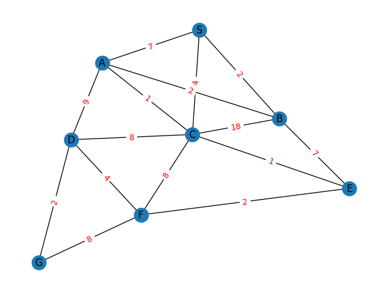

```
### BREADTH FIRST SEARCH ###
curr_node = 'S'
children = {'A': {'weight': 7}, 'B': {'weight': 2}, 'C': {'weight': 4}}
queue = ['A', 'B', 'C']
explored = ['S']
cost = 0


curr_node = 'A'
children = {'S': {'weight': 7}, 'B': {'weight': 2}, 'C': {'weight': 1}, 'D': {'weight': 9}}
queue = ['B', 'C', 'D']
explored = ['S', 'A']
cost = 7


curr_node = 'B'
children = {'S': {'weight': 2}, 'A': {'weight': 2}, 'C': {'weight': 18}, 'E': {'weight': 7}}
queue = ['C', 'D', 'E']
explored = ['S', 'A', 'B']
cost = 9


curr_node = 'C'
children = {'S': {'weight': 4}, 'A': {'weight': 1}, 'B': {'weight': 18}, 'D': {'weight': 8}, 'E': {'weight': 1}, 'F': {'weight': 8}}
queue = ['D', 'E', 'F']
explored = ['S', 'A', 'B', 'C']
cost = 27


curr_node = 'D'
children = {'A': {'weight': 9}, 'C': {'weight': 8}, 'F': {'weight': 4}, 'G': {'weight': 2}}
queue = ['E', 'F', 'G']
explored = ['S', 'A', 'B', 'C', 'D']
cost = 35


curr_node = 'E'
children = {'B': {'weight': 7}, 'C': {'weight': 1}, 'F': {'weight': 2}}
queue = ['F', 'G']
explored = ['S', 'A', 'B', 'C', 'D', 'E']
```

[output cut: 75 more lines]

```
children = [(34, 'S'), (16, 'A'), (43, 'B'), (13, 'D'), (19, 'E'), (13, 'F')]
queue = [(22, 'A'), (27, 'B'), (16, 'A'), (43, 'B'), (13, 'D'), (19, 'E'), (13, 'F')]
explored = ['S', 'C']
cost = 4


curr_node = 'D'
children = [(24, 'A'), (25, 'C'), (9, 'F'), (2, 'G')]
queue = [(13, 'F'), (16, 'A'), (19, 'E'), (22, 'A'), (27, 'B'), (43, 'B'), (24, 'A'), (9, 'F'), (2, 'G')]
explored = ['S', 'C', 'D']
cost = 12


found goal G
cost = 14
```

```python
# source: searches on graph 1
graph = nx.Graph()

graph.add_node("S", goal=False, heuristic=30)
graph.add_node("A", goal=False, heuristic=15)
graph.add_node("B", goal=False, heuristic=25)
graph.add_node("C", goal=False, heuristic=17)
graph.add_node("D", goal=False, heuristic=5)
graph.add_node("E", goal=False, heuristic=18)
graph.add_node("F", goal=False, heuristic=5)
graph.add_node("G", goal=True, heuristic=0)

edges: list[tuple[str, str, dict[str, int]]] = [
    ("S", "A", {"weight": 7}),
    ("S", "B", {"weight": 2}),
    ("S", "C", {"weight": 4}),
    ("A", "B", {"weight": 2}),
    ("A", "C", {"weight": 1}),
    ("A", "D", {"weight": 9}),
    ("B", "C", {"weight": 18}),
    ("B", "E", {"weight": 7}),
    ("C", "D", {"weight": 8}),
    ("C", "E", {"weight": 1}),
    ("C", "F", {"weight": 8}),
    ("D", "F", {"weight": 4}),
    ("D", "G", {"weight": 2}),
    ("E", "F", {"weight": 2}),
    ("F", "G", {"weight": 8}),
]

graph.add_edges_from(edges)

plot_graph(graph)
breadth_first_search(graph, "S")
depth_first_search(graph, "S")
greedy_best_first_search(graph, "S")
a_star_search(graph, "S")
```

# 2.3.2

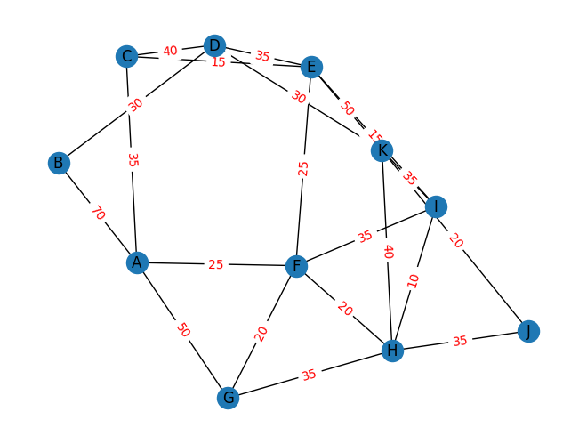

```
### BREADTH FIRST SEARCH ###
curr_node = 'A'
children = {'B': {'weight': 70}, 'C': {'weight': 35}, 'F': {'weight': 25}, 'G': {'weight': 50}}
queue = ['B', 'C', 'F', 'G']
explored = ['A']
cost = 0


curr_node = 'B'
children = {'A': {'weight': 70}, 'D': {'weight': 30}}
queue = ['C', 'F', 'G', 'D']
explored = ['A', 'B']
cost = 70


curr_node = 'C'
children = {'A': {'weight': 35}, 'D': {'weight': 40}, 'E': {'weight': 15}}
queue = ['F', 'G', 'D', 'E']
explored = ['A', 'B', 'C']
cost = 70


curr_node = 'F'
children = {'A': {'weight': 25}, 'E': {'weight': 25}, 'G': {'weight': 20}, 'H': {'weight': 20}, 'I': {'weight': 35}}
queue = ['G', 'D', 'E', 'H', 'I']
explored = ['A', 'B', 'C', 'F']
cost = 70


curr_node = 'G'
children = {'A': {'weight': 50}, 'F': {'weight': 20}, 'H': {'weight': 35}}
queue = ['D', 'E', 'H', 'I']
explored = ['A', 'B', 'C', 'F', 'G']
cost = 90


curr_node = 'D'
children = {'B': {'weight': 30}, 'C': {'weight': 40}, 'E': {'weight': 35}, 'K': {'weight': 30}}
queue = ['E', 'H', 'I', 'K']
explored = ['A', 'B', 'C', 'F', 'G', 'D']
```

[output cut: 89 more lines]

```
children = [(175, 'A'), (75, 'E'), (160, 'G'), (60, 'H'), (70, 'I')]
queue = [(145, 'C'), (170, 'B'), (190, 'G'), (75, 'E'), (160, 'G'), (60, 'H'), (70, 'I')]
explored = ['A', 'F']
cost = 25


curr_node = 'H'
children = [(130, 'F'), (175, 'G'), (45, 'I'), (55, 'J'), (40, 'K')]
queue = [(70, 'I'), (75, 'E'), (145, 'C'), (160, 'G'), (170, 'B'), (190, 'G'), (175, 'G'), (45, 'I'), (55, 'J'), (40, 'K')]
explored = ['A', 'F', 'H']
cost = 45


found goal K
cost = 85
```

```python
# source: searches on graph 2
graph = nx.Graph()

graph.add_node("A", goal=False, heuristic=150)
graph.add_node("B", goal=False, heuristic=100)
graph.add_node("C", goal=False, heuristic=110)
graph.add_node("D", goal=False, heuristic=30)
graph.add_node("E", goal=False, heuristic=50)
graph.add_node("F", goal=False, heuristic=110)
graph.add_node("G", goal=False, heuristic=140)
graph.add_node("H", goal=False, heuristic=40)
graph.add_node("I", goal=False, heuristic=35)
graph.add_node("J", goal=False, heuristic=20)
graph.add_node("K", goal=True, heuristic=0)


edges: list[tuple[str, str, dict[str, int]]] = [
    ("A", "B", {"weight": 70}),
    ("A", "C", {"weight": 35}),
    ("A", "F", {"weight": 25}),
    ("A", "G", {"weight": 50}),
    ("B", "D", {"weight": 30}),
    ("C", "D", {"weight": 40}),
    ("C", "E", {"weight": 15}),
    ("D", "E", {"weight": 35}),
    ("D", "K", {"weight": 30}),
    ("E", "F", {"weight": 25}),
    ("E", "I", {"weight": 15}),
    ("E", "K", {"weight": 50}),
    ("F", "G", {"weight": 20}),
    ("F", "H", {"weight": 20}),
    ("F", "I", {"weight": 35}),
    ("G", "H", {"weight": 35}),
    ("H", "I", {"weight": 10}),
    ("H", "J", {"weight": 35}),
    ("H", "K", {"weight": 40}),
    ("I", "K", {"weight": 35}),
    ("J", "K", {"weight": 20}),
]

graph.add_edges_from(edges)

plot_graph(graph)

breadth_first_search(graph, "A")
depth_first_search(graph, "A")
greedy_best_first_search(graph, "A")
a_star_search(graph, "A")
```

# 2.4.1

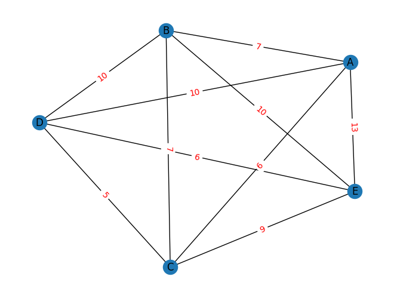

```
curr_node = 'A'
queue = [(6.0, 'C'), (7.0, 'B'), (10.0, 'D'), (13.0, 'E')]
curr_node = 'C'
queue = [(5.0, 'D'), (7.0, 'B'), (9.0, 'E')]
curr_node = 'D'
queue = [(6.0, 'E'), (10.0, 'B')]
curr_node = 'E'
queue = [(10.0, 'B')]
curr_node = 'B'
queue = []
```

```
[('A', 0), ('C', 6.0), ('D', 11.0), ('E', 17.0), ('B', 27.0), ('A', 34.0)]
```

```python
# source: nearest neighbour solution to TSP
def tsp_nn(graph: nx.Graph, start_node: str):
    matrix = nx.to_numpy_array(graph, nonedge=np.inf)
    node_list = list(graph.nodes)
    queue = [(0, start_node)]
    explored, route = [], []
    cost = 0

    while len(explored) < len(matrix[0]):
        weight, curr_node = queue.pop(0)
        explored.append((curr_node))
        cost += weight
        route.append((curr_node, cost))

        queue = sorted(
            [
                (weight, node_list[idx])
                for idx, weight in enumerate(matrix[node_list.index(curr_node)])
                if node_list[idx] not in explored
            ]
        )

        print(f"{curr_node = }")
        print(f"{queue = }")

    route.append(
        (
            start_node,
            cost + matrix[node_list.index(curr_node)][node_list.index(start_node)],
        )
    )
    return route


graph = nx.Graph()

graph.add_node("A", goal=False, heuristic=0)
graph.add_node("B", goal=False, heuristic=0)
graph.add_node("C", goal=False, heuristic=0)
graph.add_node("D", goal=False, heuristic=0)
graph.add_node("E", goal=False, heuristic=0)


edges: list[tuple[str, str, dict[str, int]]] = [
    ("A", "B", {"weight": 7}),
    ("A", "C", {"weight": 6}),
    ("A", "D", {"weight": 10}),
    ("A", "E", {"weight": 13}),
    ("B", "C", {"weight": 7}),
    ("B", "D", {"weight": 10}),
    ("B", "E", {"weight": 10}),
    ("C", "D", {"weight": 5}),
    ("C", "E", {"weight": 9}),
    ("D", "E", {"weight": 6}),
]

graph.add_edges_from(edges)
plot_graph(graph)

tsp_nn(graph, "A")
```

## References

[1] https://www.techtarget.com/searchenterpriseai/definition/Turing-test

[2] https://medium.com/basecs/breaking-down-breadth-first-search-cebe696709d9

[3] https://shivharibaral.medium.com/informed-search-vs-uninformed-search-in-ai-802f95260304

[4] https://yuminlee2.medium.com/a-search-algorithm-42c1a13fcf9f